# Modeling and prediction for movies

John Wu

2020.05.14

## Setup

### Load packages

```r
library(ggplot2)
library(dplyr)
library(statsr)
library(knitr)
```

### Load data

```r
load("movies.Rdata")
```

## Part 1: Data

*1.1 Data information*  
The data set is comprised of 651 randomly sampled movies produced and released before 2016. And it includes 32 variables of each movie.like movie information,some scores from IMDb and Rotten Tomatoes, and some information about the actor and director.

*1.2 Generabizability*  
This data is random sampled, so it can be generalized to all the audience within 11 related genres.

*1.3 Causality*  
This data is just an obervation, not an experiment,So we can not conclude any causality.

*1.4 Potential bias*  
The potential bias is the rating and score is only collected from website in IMDb and Rotten Tomatoes,furthermore, this is limited in users who sign up these two websites and also willing to write something.There is non-response bias in it.

## Part 2: Research question

In the given scenario,Our boss is interested in learning what attributes makes a movie popular.And for myself, I like watching movies very much, but there are too many movies released every year. In order to judge whether a movie is worth watching, I will go to the movie rating website to see comments and scores. So in this project, I will use the audience_score in the data set as a judgment of whether a movie is popular, and find out whether other variables in the data set can be used to predict audience_score.

## Part 3: Exploratory data analysis

*3.1 Summary*  
At first, we check the summary of this data set and find some information.

```r
summary(movies)
```

```
##     title                  title_type                 genre        runtime
##  Length:651         Documentary : 55   Drama             :305   Min.   : 39.0
##  Class :character   Feature Film:591   Comedy            : 87   1st Qu.: 92.0
##  Mode  :character   TV Movie    :  5   Action & Adventure: 65   Median :103.0
##                                        Mystery & Suspense: 59   Mean   :105.8
##                                        Documentary       : 52   3rd Qu.:115.8
##                                        Horror            : 23   Max.   :267.0
##                                        (Other)           : 60   NA's   :1
##   mpaa_rating                               studio    thtr_rel_year
##  G      : 19   Paramount Pictures              : 37   Min.   :1970
##  NC-17  :  2   Warner Bros. Pictures           : 30   1st Qu.:1990
##  PG     :118   Sony Pictures Home Entertainment: 27   Median :2000
##  PG-13  :133   Universal Pictures              : 23   Mean   :1998
##  R      :329   Warner Home Video               : 19   3rd Qu.:2007
##  Unrated: 50   (Other)                         :507   Max.   :2014
##                NA's                            :  8
##  thtr_rel_month   thtr_rel_day    dvd_rel_year  dvd_rel_month
##  Min.   : 1.00   Min.   : 1.00   Min.   :1991   Min.   : 1.000
##  1st Qu.: 4.00   1st Qu.: 7.00   1st Qu.:2001   1st Qu.: 3.000
##  Median : 7.00   Median :15.00   Median :2004   Median : 6.000
##  Mean   : 6.74   Mean   :14.42   Mean   :2004   Mean   : 6.333
##  3rd Qu.:10.00   3rd Qu.:21.00   3rd Qu.:2008   3rd Qu.: 9.000
##  Max.   :12.00   Max.   :31.00   Max.   :2015   Max.   :12.000
##                                  NA's   :8      NA's   :8
##   dvd_rel_day     imdb_rating    imdb_num_votes           critics_rating
##  Min.   : 1.00   Min.   :1.900   Min.   :   180   Certified Fresh:135
##  1st Qu.: 7.00   1st Qu.:5.900   1st Qu.:  4546   Fresh          :209
##  Median :15.00   Median :6.600   Median : 15116   Rotten         :307
##  Mean   :15.01   Mean   :6.493   Mean   : 57533
##  3rd Qu.:23.00   3rd Qu.:7.300   3rd Qu.: 58300
##  Max.   :31.00   Max.   :9.000   Max.   :893008
##  NA's   :8
##  critics_score    audience_rating audience_score  best_pic_nom best_pic_win
##  Min.   :  1.00   Spilled:275     Min.   :11.00   no :629      no :644
##  1st Qu.: 33.00   Upright:376     1st Qu.:46.00   yes: 22      yes:  7
##  Median : 61.00                   Median :65.00
##  Mean   : 57.69                   Mean   :62.36
##  3rd Qu.: 83.00                   3rd Qu.:80.00
##  Max.   :100.00                   Max.   :97.00
##
```

[output cut: 9 more lines]

```
##  Length:651         Length:651         Length:651         Length:651
##  Class :character   Class :character   Class :character   Class :character
##  Mode  :character   Mode  :character   Mode  :character   Mode  :character
##
##
##
##
##     actor5            imdb_url            rt_url
##  Length:651         Length:651         Length:651
##  Class :character   Class :character   Class :character
##  Mode  :character   Mode  :character   Mode  :character
##
##
##
##
```

*3.2 Plot of numerical variables*  
(1)runtime

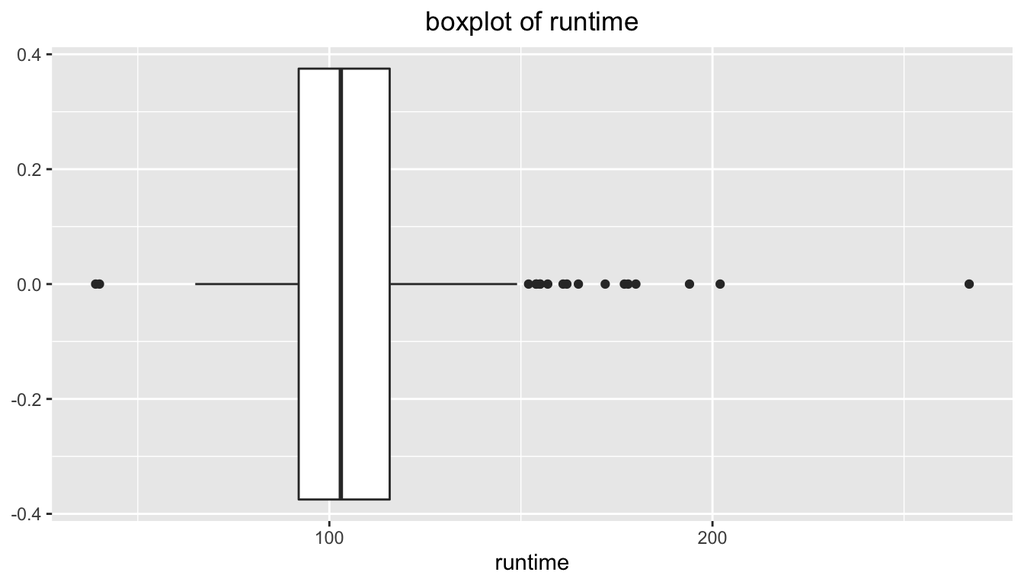

```r
ggplot(data = movies, aes(y = runtime)) + geom_boxplot() + coord_flip() +  ggtitle('boxplot of runtime')+theme(plot.title=element_text(hjust=0.5))
```

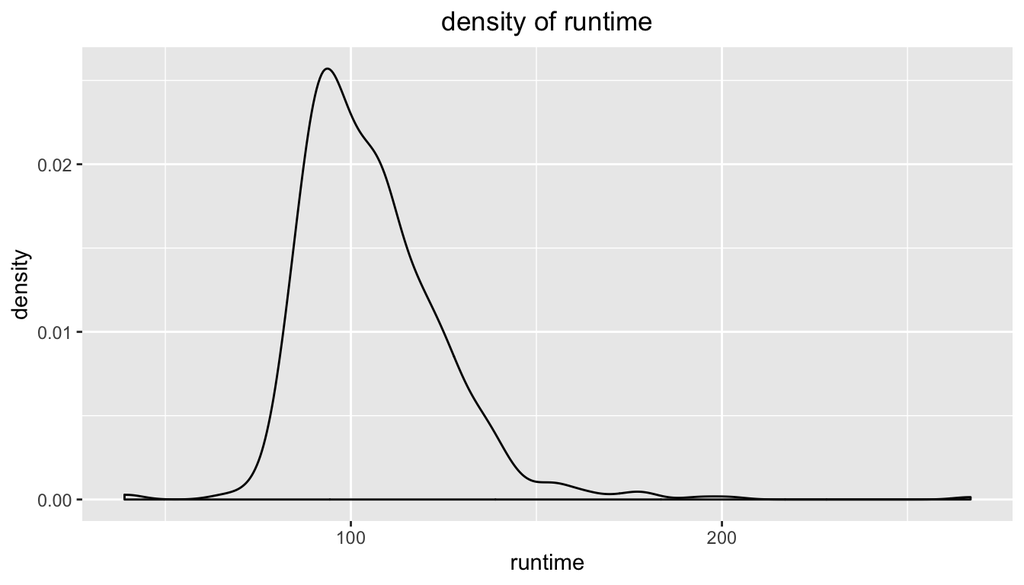

```r
ggplot(data = movies, aes(x = runtime)) + geom_density() +  ggtitle('density of runtime')+theme(plot.title=element_text(hjust=0.5))
```

(2)ther_rel_year

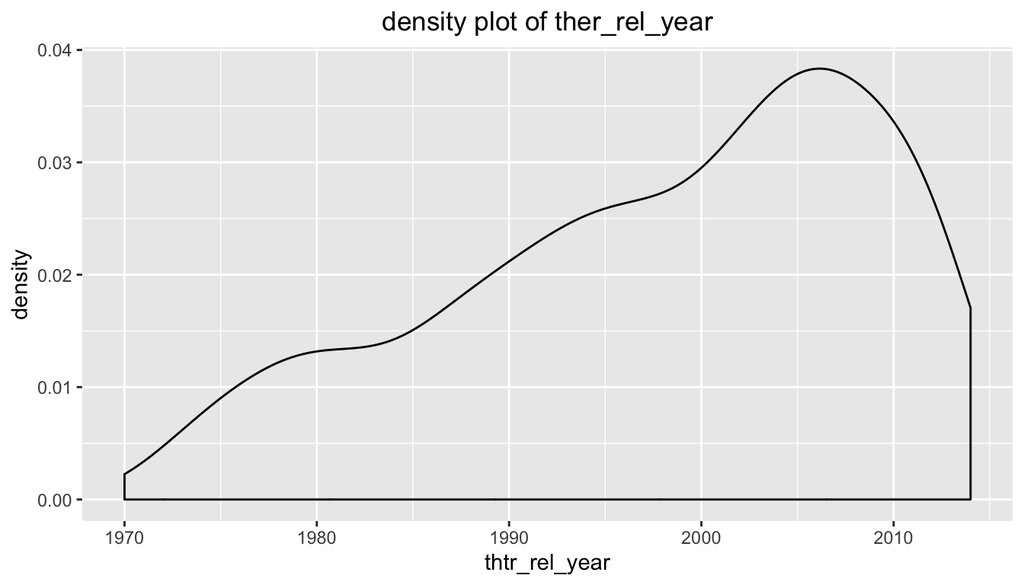

```r
ggplot(data = movies, aes(x = thtr_rel_year)) + geom_density() + ggtitle('density plot of ther_rel_year') + theme(plot.title=element_text(hjust=0.5))
```

(3)imdb_rating

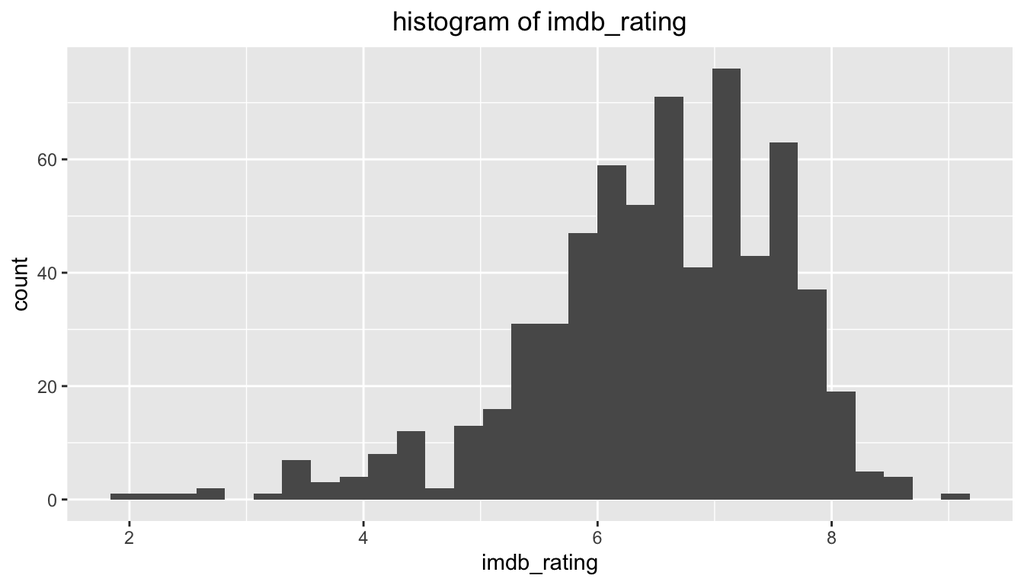

```r
ggplot(data = movies, aes(x = imdb_rating)) + geom_histogram() + ggtitle('histogram of imdb_rating') + theme(plot.title=element_text(hjust=0.5))
```

(4)imdb_num_votes

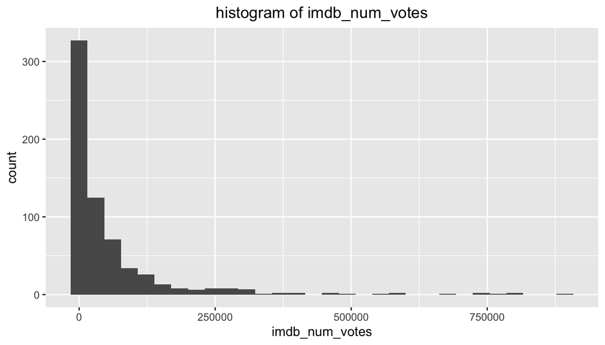

```r
ggplot(data = movies, aes(x = imdb_num_votes)) + geom_histogram() + ggtitle('histogram of imdb_num_votes') + theme(plot.title=element_text(hjust=0.5))
```

(5)critics_score

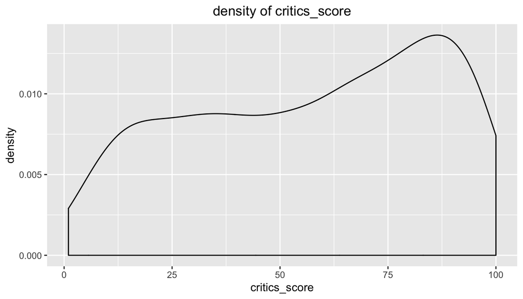

```r
ggplot(data = movies, aes(x = critics_score)) + geom_density() + ggtitle('density of critics_score') + theme(plot.title=element_text(hjust=0.5))
```

(6)audience_score

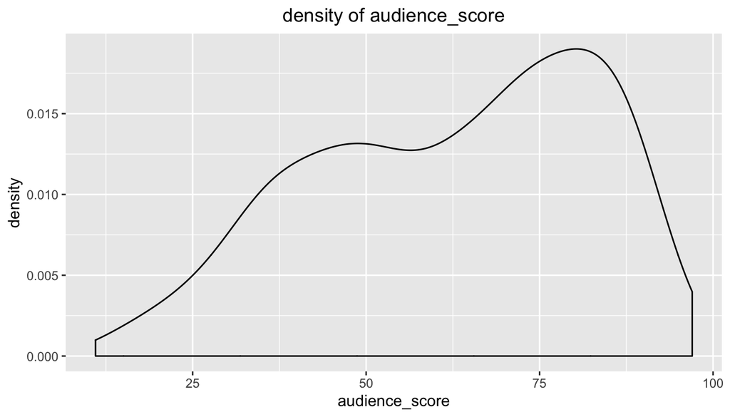

```r
ggplot(data = movies, aes(x = audience_score)) + geom_density() + ggtitle('density of audience_score') + theme(plot.title=element_text(hjust=0.5))
```

**Observations:**  
(1)runtime: the plot is right skewed.  
(2)ther_rel_year: the plot is left skewed, and in general, The closer we get to the present era, the more movies been released every year.  
(3)imdb_rating: the rating score is focus on around 7 points.  
(4)imdb_num_votes:The vast majority of films have a small number of votes, 75% of which are less than 58300.(3rd IQR in summary result)  
(5)critics_score:The score mainly focuses on about 20-90 points, and the most commonly score is about 75-85 points.  
(6)audience_score:he score mainly focuses on about 40-80 points, and the most commonly score is about 75-80 points.

*3.3 Plot of Non-numerical variables*  
(1)genre

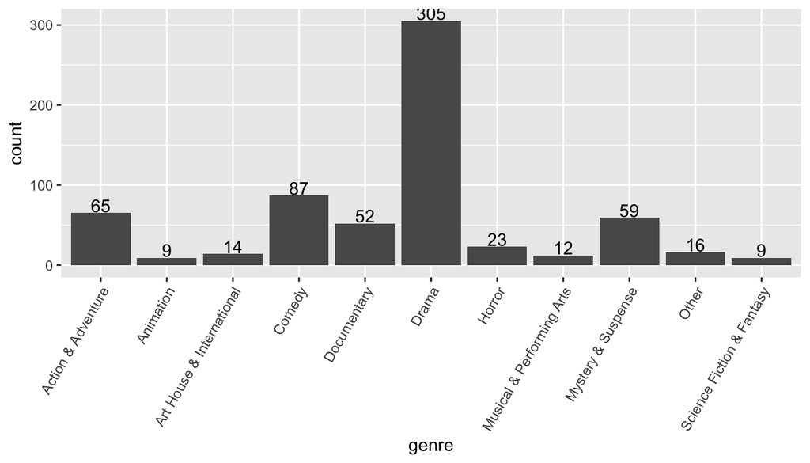

```r
ggplot(data = movies, aes(x = genre)) + geom_bar() + theme(axis.text.x = element_text(angle = 60, hjust = 1)) + geom_text(aes(label=as.character(..count..)),stat="count",vjust = -0.1)
```

(2)audience_rating

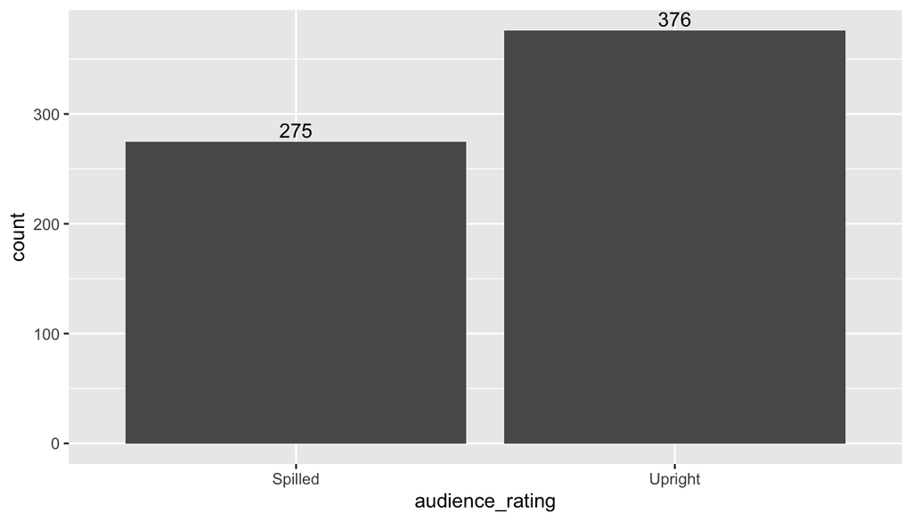

```r
ggplot(data = movies, aes(x = audience_rating)) + geom_bar() +  geom_text(aes(label=as.character(..count..)),stat="count",vjust=-0.3)
```

(3)best_pic_nom

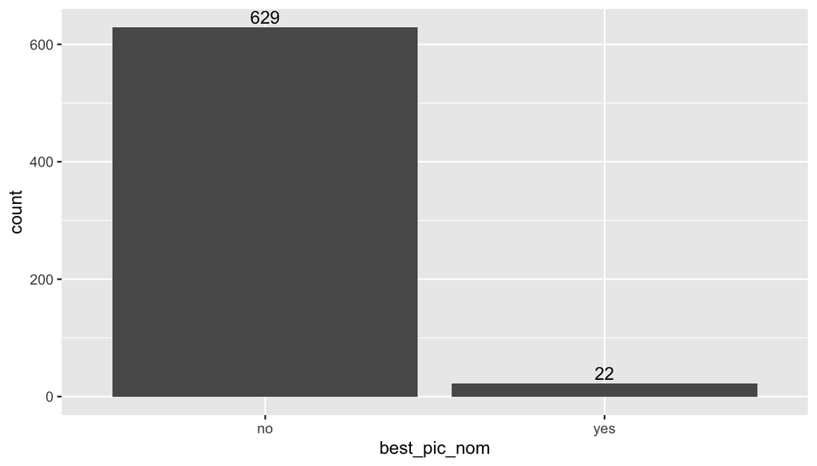

```r
ggplot(data = movies, aes(x = best_pic_nom)) + geom_bar() +  geom_text(aes(label=as.character(..count..)),stat="count",vjust=-0.3)
```

(4)best_pic_win

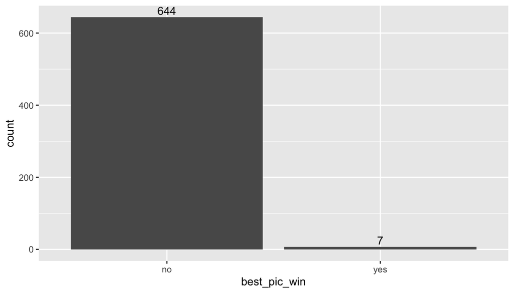

```r
ggplot(data = movies, aes(x = best_pic_win)) + geom_bar() +  geom_text(aes(label=as.character(..count..)),stat="count",vjust=-0.3)
```

(5)best_dir_win

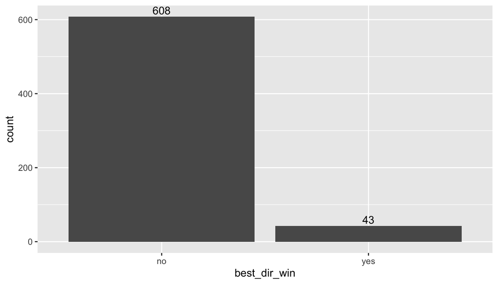

```r
ggplot(data = movies, aes(x = best_dir_win)) + geom_bar() +  geom_text(aes(label=as.character(..count..)),stat="count",vjust=-0.3)
```

**Observations:**  
(1)genere: There are 46.9% movies are ‘Drama’, and two genres(‘Animation’, ‘Science Fiction & Fantasy’) have movies less than 10.  
(2)audience_rating: The proportion of ‘Spilled’ is 42.2%(275 in 651), and for ‘Upright’ is 57.8%(376 in 651)  
(3)best_pic_nom: Only 3.4%(22 in 651) movies get Oscar best picture nomination.  
(4)best_pic_win: Merely 1.1%(7 in 651) movies win the best best picture of Oscar.  
(5)best_dir_win: There are 6.6%(43 in 651) dirctors win the best director of Oscar.

## Part 4: Modeling

*4.1 Define popularity*  
I use audience_score to define the popularity of a movie, as an audience I think this is the most suitable factor.

*4.2 Variables used in modeling*  
I want to chose the following variabls to build the full model: runtime, thtr_rel_year, imdb_rating, imdb_num_votes, critics_score, genre, audience_rating, best_pic_nom, best_pic_win and best_dir_win.

*4.3 Model selection method*  
In this project, I will use backwards elimination method to optimize model, And use adjusted R square to pick the most suitable model.  
*4.4 Model optimiziting*  
**Full model**  
So let’s see the full model:

```r
model0 <- lm(audience_score ~ runtime + thtr_rel_year + imdb_rating +  imdb_num_votes + critics_score + genre + audience_rating + best_pic_nom +  best_pic_win  +  best_dir_win,data = movies)
summary(model0)
```

```
##
## Call:
## lm(formula = audience_score ~ runtime + thtr_rel_year + imdb_rating +
##     imdb_num_votes + critics_score + genre + audience_rating +
##     best_pic_nom + best_pic_win + best_dir_win, data = movies)
##
## Residuals:
##      Min       1Q   Median       3Q      Max
## -22.1122  -4.5338   0.4654   4.1710  24.0955
##
## Coefficients:
##                                  Estimate Std. Error t value Pr(>|t|)
## (Intercept)                     8.753e+01  5.328e+01   1.643   0.1009
## runtime                        -3.490e-02  1.625e-02  -2.147   0.0322 *
## thtr_rel_year                  -4.744e-02  2.650e-02  -1.790   0.0739 .
## imdb_rating                     9.337e+00  4.749e-01  19.663   <2e-16 ***
## imdb_num_votes                  4.196e-06  3.057e-06   1.373   0.1704
## critics_score                   1.980e-02  1.514e-02   1.308   0.1915
## genreAnimation                  3.340e+00  2.460e+00   1.358   0.1750
## genreArt House & International -2.251e+00  2.049e+00  -1.099   0.2724
## genreComedy                     1.394e+00  1.131e+00   1.233   0.2181
## genreDocumentary                1.044e+00  1.482e+00   0.704   0.4817
## genreDrama                     -6.375e-01  9.820e-01  -0.649   0.5164
## genreHorror                    -2.092e+00  1.676e+00  -1.248   0.2124
## genreMusical & Performing Arts  3.273e+00  2.222e+00   1.473   0.1412
## genreMystery & Suspense        -3.078e+00  1.249e+00  -2.464   0.0140 *
## genreOther                     -4.319e-01  1.936e+00  -0.223   0.8235
## genreScience Fiction & Fantasy -3.991e-01  2.441e+00  -0.163   0.8702
## audience_ratingUpright          2.000e+01  7.790e-01  25.674   <2e-16 ***
## best_pic_nomyes                 3.437e+00  1.767e+00   1.946   0.0521 .
## best_pic_winyes                -2.979e+00  3.154e+00  -0.944   0.3453
## best_dir_winyes                 2.339e-01  1.180e+00   0.198   0.8430
## ---
## Signif. codes:  0 '***' 0.001 '**' 0.01 '*' 0.05 '.' 0.1 ' ' 1
##
## Residual standard error: 6.826 on 630 degrees of freedom
##   (1 observation deleted due to missingness)
## Multiple R-squared:  0.8895, Adjusted R-squared:  0.8862
## F-statistic:   267 on 19 and 630 DF,  p-value: < 2.2e-16
```

The adjusted R square of full model is 0.8862, and now we delete one variable at a time to find the change of adjusted R square.

**Optimization step 1**

```r
model1 <-lm(audience_score ~ thtr_rel_year + imdb_rating +  imdb_num_votes + critics_score + genre + audience_rating + best_pic_nom +  best_pic_win  +  best_dir_win,data = movies)

model2 <-lm(audience_score ~ runtime + imdb_rating +  imdb_num_votes + critics_score + genre + audience_rating + best_pic_nom +  best_pic_win  +  best_dir_win,data = movies)

model3 <-lm(audience_score ~ runtime + thtr_rel_year + imdb_num_votes + critics_score + genre + audience_rating + best_pic_nom +  best_pic_win  +  best_dir_win,data = movies)

model4 <-lm(audience_score ~ runtime + thtr_rel_year + imdb_rating  + critics_score + genre + audience_rating + best_pic_nom +  best_pic_win  +  best_dir_win,data = movies)

model5 <-lm(audience_score ~ runtime + thtr_rel_year + imdb_rating +  imdb_num_votes +  genre + audience_rating + best_pic_nom +  best_pic_win  +  best_dir_win,data = movies)

model6 <-lm(audience_score ~ runtime + thtr_rel_year + imdb_rating +  imdb_num_votes + critics_score +  audience_rating + best_pic_nom +  best_pic_win  +  best_dir_win,data = movies)

model7 <-lm(audience_score ~ runtime + thtr_rel_year + imdb_rating +  imdb_num_votes + critics_score + genre +  best_pic_nom +  best_pic_win  +  best_dir_win,data = movies)

model8 <-lm(audience_score ~ runtime + thtr_rel_year + imdb_rating +  imdb_num_votes + critics_score + genre + audience_rating +  best_pic_win  +  best_dir_win,data = movies)

model9 <-lm(audience_score ~ runtime + thtr_rel_year + imdb_rating +  imdb_num_votes + critics_score + genre + audience_rating + best_pic_nom +   best_dir_win,data = movies)

model10 <-lm(audience_score ~ runtime + thtr_rel_year + imdb_rating +  imdb_num_votes + critics_score + genre + audience_rating + best_pic_nom +  best_pic_win,data = movies)
```

then we creat a table to show each model’s adjusted R square.

```r
kable(data.frame(Model = c("Full model","Model 1","Model  2","Model 3","Model 4","Model 5","Model 6","Model 7","Model 8","Model 9","Model 10"),Adjusted_R_Square = c(summary(model0)$adj.r.squared,summary(model1)$adj.r.squared,summary(model2)$adj.r.squared,summary(model3)$adj.r.squared,summary(model4)$adj.r.squared,summary(model5)$adj.r.squared,summary(model6)$adj.r.squared,summary(model7)$adj.r.squared,summary(model8)$adj.r.squared,summary(model9)$adj.r.squared,summary(model10)$adj.r.squared)))
```

| Model | Adjusted_R_Square |
| --- | --- |
| Full model | 0.8861880 |
| Model 1 | 0.8852313 |
| Model 2 | 0.8857903 |
| Model 3 | 0.8166297 |
| Model 4 | 0.8860285 |
| Model 5 | 0.8860600 |
| Model 6 | 0.8834993 |
| Model 7 | 0.7674790 |
| Model 8 | 0.8856856 |
| Model 9 | 0.8862074 |
| Model 10 | 0.8863613 |

From this step,we find that mode 10 has the highest adjusted R square 0.8863613. the deleted variable is best_dir_win.then we delete each one again to get the model with highest adjusted R square.  
**Optimization step 2**

```r
model0 <-lm(audience_score ~ runtime + thtr_rel_year + imdb_rating +  imdb_num_votes + critics_score + genre + audience_rating + best_pic_nom +  best_pic_win,data = movies)

model1 <-lm(audience_score ~ thtr_rel_year + imdb_rating +  imdb_num_votes + critics_score + genre + audience_rating + best_pic_nom +  best_pic_win,data = movies)

model2 <-lm(audience_score ~ runtime + imdb_rating +  imdb_num_votes + critics_score + genre + audience_rating + best_pic_nom +  best_pic_win,data = movies)

model3 <-lm(audience_score ~ runtime + thtr_rel_year +  imdb_num_votes + critics_score + genre + audience_rating + best_pic_nom +  best_pic_win,data = movies)

model4 <-lm(audience_score ~ runtime + thtr_rel_year + imdb_rating + critics_score + genre + audience_rating + best_pic_nom +  best_pic_win,data = movies)

model5 <-lm(audience_score ~ runtime + thtr_rel_year + imdb_rating +  imdb_num_votes + genre + audience_rating + best_pic_nom +  best_pic_win,data = movies)

model6 <-lm(audience_score ~ runtime + thtr_rel_year + imdb_rating +  imdb_num_votes + critics_score + audience_rating + best_pic_nom +  best_pic_win,data = movies)

model7 <-lm(audience_score ~ runtime + thtr_rel_year + imdb_rating +  imdb_num_votes + critics_score + genre + best_pic_nom +  best_pic_win,data = movies)

model8 <-lm(audience_score ~ runtime + thtr_rel_year + imdb_rating +  imdb_num_votes + critics_score + genre + audience_rating  +  best_pic_win,data = movies)

model9 <-lm(audience_score ~ runtime + thtr_rel_year + imdb_rating +  imdb_num_votes + critics_score + genre + audience_rating + best_pic_nom,data = movies)

kable(data.frame(Model = c("Full model","Model 1","Model  2","Model 3","Model 4","Model 5","Model 6","Model 7","Model 8","Model 9"),Adjusted_R_Square = c(summary(model0)$adj.r.squared,summary(model1)$adj.r.squared,summary(model2)$adj.r.squared,summary(model3)$adj.r.squared,summary(model4)$adj.r.squared,summary(model5)$adj.r.squared,summary(model6)$adj.r.squared,summary(model7)$adj.r.squared,summary(model8)$adj.r.squared,summary(model9)$adj.r.squared)))
```

| Model | Adjusted_R_Square |
| --- | --- |
| Full model | 0.8863613 |
| Model 1 | 0.8854097 |
| Model 2 | 0.8859522 |
| Model 3 | 0.8167948 |
| Model 4 | 0.8861983 |
| Model 5 | 0.8862260 |
| Model 6 | 0.8836785 |
| Model 7 | 0.7676440 |
| Model 8 | 0.8858653 |
| Model 9 | 0.8863869 |

From this step,we find that mode 9 has the highest adjusted R square 0.8863869. the deleted variable is best_pic_win.then we delete each one again to get the model with highest adjusted R square.

**Optimization step 3**

```r
model0 <-lm(audience_score ~ runtime + thtr_rel_year + imdb_rating +  imdb_num_votes + critics_score + genre + audience_rating + best_pic_nom,data = movies)

model1 <-lm(audience_score ~thtr_rel_year + imdb_rating +  imdb_num_votes + critics_score + genre + audience_rating + best_pic_nom,data = movies)

model2 <-lm(audience_score ~ runtime + imdb_rating +  imdb_num_votes + critics_score + genre + audience_rating + best_pic_nom,data = movies)

model3 <-lm(audience_score ~ runtime + thtr_rel_year  +  imdb_num_votes + critics_score + genre + audience_rating + best_pic_nom,data = movies)

model4 <-lm(audience_score ~ runtime + thtr_rel_year + imdb_rating +   critics_score + genre + audience_rating + best_pic_nom,data = movies)

model5 <-lm(audience_score ~ runtime + thtr_rel_year + imdb_rating +  imdb_num_votes + genre + audience_rating + best_pic_nom,data = movies)

model6 <-lm(audience_score ~ runtime + thtr_rel_year + imdb_rating +  imdb_num_votes + critics_score + audience_rating + best_pic_nom,data = movies)

model7 <-lm(audience_score ~ runtime + thtr_rel_year + imdb_rating +  imdb_num_votes + critics_score + genre + best_pic_nom,data = movies)

model8 <-lm(audience_score ~ runtime + thtr_rel_year + imdb_rating +  imdb_num_votes + critics_score + genre + audience_rating,data = movies)

kable(data.frame(Model = c("Full model","Model 1","Model  2","Model 3","Model 4","Model 5","Model 6","Model 7","Model 8"),Adjusted_R_Square = c(summary(model0)$adj.r.squared,summary(model1)$adj.r.squared,summary(model2)$adj.r.squared,summary(model3)$adj.r.squared,summary(model4)$adj.r.squared,summary(model5)$adj.r.squared,summary(model6)$adj.r.squared,summary(model7)$adj.r.squared,summary(model8)$adj.r.squared)))
```

| Model | Adjusted_R_Square |
| --- | --- |
| Full model | 0.8863869 |
| Model 1 | 0.8854092 |
| Model 2 | 0.8860251 |
| Model 3 | 0.8165705 |
| Model 4 | 0.8863000 |
| Model 5 | 0.8862623 |
| Model 6 | 0.8837440 |
| Model 7 | 0.7676810 |
| Model 8 | 0.8860409 |

From this step,we find that full model has the highest adjusted R square 0.8863869, delete one variable can not increase it, but we notice that adjusted R square of model 4 is 0.8863000,this is so close to full model.so we check the summary of full model.

```r
summary(model0)
```

```
##
## Call:
## lm(formula = audience_score ~ runtime + thtr_rel_year + imdb_rating +
##     imdb_num_votes + critics_score + genre + audience_rating +
##     best_pic_nom, data = movies)
##
## Residuals:
##      Min       1Q   Median       3Q      Max
## -22.0902  -4.5010   0.4945   4.1659  24.1205
##
## Coefficients:
##                                  Estimate Std. Error t value Pr(>|t|)
## (Intercept)                     8.399e+01  5.293e+01   1.587   0.1131
## runtime                        -3.494e-02  1.605e-02  -2.177   0.0298 *
## thtr_rel_year                  -4.569e-02  2.631e-02  -1.737   0.0830 .
## imdb_rating                     9.357e+00  4.738e-01  19.748   <2e-16 ***
## imdb_num_votes                  3.641e-06  2.989e-06   1.218   0.2236
## critics_score                   1.964e-02  1.509e-02   1.301   0.1936
## genreAnimation                  3.303e+00  2.458e+00   1.344   0.1794
## genreArt House & International -2.320e+00  2.045e+00  -1.135   0.2570
## genreComedy                     1.346e+00  1.129e+00   1.192   0.2335
## genreDocumentary                9.477e-01  1.476e+00   0.642   0.5211
## genreDrama                     -6.661e-01  9.806e-01  -0.679   0.4972
## genreHorror                    -2.117e+00  1.674e+00  -1.265   0.2064
## genreMusical & Performing Arts  3.222e+00  2.219e+00   1.452   0.1470
## genreMystery & Suspense        -3.106e+00  1.248e+00  -2.489   0.0131 *
## genreOther                     -3.234e-01  1.930e+00  -0.168   0.8670
## genreScience Fiction & Fantasy -3.697e-01  2.438e+00  -0.152   0.8795
## audience_ratingUpright          2.001e+01  7.773e-01  25.737   <2e-16 ***
## best_pic_nomyes                 2.761e+00  1.613e+00   1.711   0.0876 .
## ---
## Signif. codes:  0 '***' 0.001 '**' 0.01 '*' 0.05 '.' 0.1 ' ' 1
##
## Residual standard error: 6.82 on 632 degrees of freedom
##   (1 observation deleted due to missingness)
## Multiple R-squared:  0.8894, Adjusted R-squared:  0.8864
## F-statistic: 298.8 on 17 and 632 DF,  p-value: < 2.2e-16
```

From this summary, we find that imdb_num_votes variable has a P value of 0.2236, this is a high P value and it is the variable we deleted in model 4, so we delete it for the parsimonious model, this is what we called expert opinion.  
So let’s look at our new full model, and decide if we can optimize it further.

```r
model0 <-lm(audience_score ~ runtime + thtr_rel_year + imdb_rating +   critics_score + genre + audience_rating + best_pic_nom,data = movies)

summary(model0)
```

```
##
## Call:
## lm(formula = audience_score ~ runtime + thtr_rel_year + imdb_rating +
##     critics_score + genre + audience_rating + best_pic_nom, data = movies)
##
## Residuals:
##      Min       1Q   Median       3Q      Max
## -21.8380  -4.5298   0.4595   4.1912  24.4826
##
## Coefficients:
##                                Estimate Std. Error t value Pr(>|t|)
## (Intercept)                    64.55160   50.48989   1.279  0.20154
## runtime                        -0.03013    0.01556  -1.937  0.05325 .
## thtr_rel_year                  -0.03648    0.02521  -1.447  0.14842
## imdb_rating                     9.49602    0.46014  20.637  < 2e-16 ***
## critics_score                   0.01927    0.01509   1.277  0.20221
## genreAnimation                  3.24210    2.45802   1.319  0.18765
## genreArt House & International -2.68615    2.02357  -1.327  0.18484
## genreComedy                     1.26269    1.12688   1.121  0.26292
## genreDocumentary                0.41436    1.41045   0.294  0.76903
## genreDrama                     -0.89296    0.96309  -0.927  0.35418
## genreHorror                    -2.19890    1.67332  -1.314  0.18929
## genreMusical & Performing Arts  2.76828    2.18832   1.265  0.20633
## genreMystery & Suspense        -3.22804    1.24415  -2.595  0.00969 **
## genreOther                     -0.29795    1.93026  -0.154  0.87738
## genreScience Fiction & Fantasy -0.25304    2.43738  -0.104  0.91735
## audience_ratingUpright         20.04823    0.77679  25.809  < 2e-16 ***
## best_pic_nomyes                 3.19969    1.57329   2.034  0.04239 *
## ---
## Signif. codes:  0 '***' 0.001 '**' 0.01 '*' 0.05 '.' 0.1 ' ' 1
##
## Residual standard error: 6.823 on 633 degrees of freedom
##   (1 observation deleted due to missingness)
## Multiple R-squared:  0.8891, Adjusted R-squared:  0.8863
## F-statistic: 317.2 on 16 and 633 DF,  p-value: < 2.2e-16
```

It seems that the variable critics_score can be droped, let’s do the optimization once more.

**Optimization step 4**

```r
model0 <-lm(audience_score ~ runtime + thtr_rel_year + imdb_rating +   critics_score + genre + audience_rating + best_pic_nom,data = movies)

model1 <-lm(audience_score ~ thtr_rel_year + imdb_rating + critics_score + genre + audience_rating + best_pic_nom,data = movies)

model2 <-lm(audience_score ~ runtime + imdb_rating + critics_score + genre + audience_rating + best_pic_nom,data = movies)

model3 <-lm(audience_score ~ runtime + thtr_rel_year + critics_score + genre + audience_rating + best_pic_nom,data = movies)

model4 <-lm(audience_score ~ runtime + thtr_rel_year + imdb_rating + genre + audience_rating + best_pic_nom,data = movies)

model5 <-lm(audience_score ~ runtime + thtr_rel_year + imdb_rating +   critics_score + audience_rating + best_pic_nom,data = movies)

model6 <-lm(audience_score ~ runtime + thtr_rel_year + imdb_rating +   critics_score + genre + best_pic_nom,data = movies)

model7 <-lm(audience_score ~ runtime + thtr_rel_year + imdb_rating +   critics_score + genre + audience_rating,data = movies)

kable(data.frame(Model = c("Full model","Model 1","Model  2","Model 3","Model 4","Model 5","Model 6","Model 7"),Adjusted_R_Square = c(summary(model0)$adj.r.squared,summary(model1)$adj.r.squared,summary(model2)$adj.r.squared,summary(model3)$adj.r.squared,summary(model4)$adj.r.squared,summary(model5)$adj.r.squared,summary(model6)$adj.r.squared,summary(model7)$adj.r.squared)))
```

| Model | Adjusted_R_Square |
| --- | --- |
| Full model | 0.8863000 |
| Model 1 | 0.8854992 |
| Model 2 | 0.8861039 |
| Model 3 | 0.8100990 |
| Model 4 | 0.8861871 |
| Model 5 | 0.8837165 |
| Model 6 | 0.7670222 |
| Model 7 | 0.8857376 |

Again the full model has the highest adjusted r square, but given the P value of critics_score and the adjusted R square of model 4, we drop variable critics_score. Also we do optimization once more.  
**Optimization step 5**

```r
model0 <-lm(audience_score ~ runtime + thtr_rel_year + imdb_rating + genre + audience_rating + best_pic_nom,data = movies)

model1 <-lm(audience_score ~ thtr_rel_year + imdb_rating + genre + audience_rating + best_pic_nom,data = movies)

model2 <-lm(audience_score ~ runtime + imdb_rating + genre + audience_rating + best_pic_nom,data = movies)

model3 <-lm(audience_score ~ runtime + thtr_rel_year + genre + audience_rating + best_pic_nom,data = movies)

model4 <-lm(audience_score ~ runtime + thtr_rel_year + imdb_rating  + audience_rating + best_pic_nom,data = movies)

model5 <-lm(audience_score ~ runtime + thtr_rel_year + imdb_rating + genre + best_pic_nom,data = movies)

model6 <-lm(audience_score ~ runtime + thtr_rel_year + imdb_rating + genre + audience_rating,data = movies)

kable(data.frame(Model = c("Full model","Model 1","Model  2","Model 3","Model 4","Model 5","Model 6"),Adjusted_R_Square = c(summary(model0)$adj.r.squared,summary(model1)$adj.r.squared,summary(model2)$adj.r.squared,summary(model3)$adj.r.squared,summary(model4)$adj.r.squared,summary(model5)$adj.r.squared,summary(model6)$adj.r.squared)))
```

| Model | Adjusted_R_Square |
| --- | --- |
| Full model | 0.8861871 |
| Model 1 | 0.8853315 |
| Model 2 | 0.8859154 |
| Model 3 | 0.7665277 |
| Model 4 | 0.8835544 |
| Model 5 | 0.7646592 |
| Model 6 | 0.8855643 |

The same scene again, full model has the highest adjusted R square, and I do not decide to use expert opinion any more, so this is our final model.

*4.5 Model diagnostics*

**4.5.1 Linear relationships between x and y**

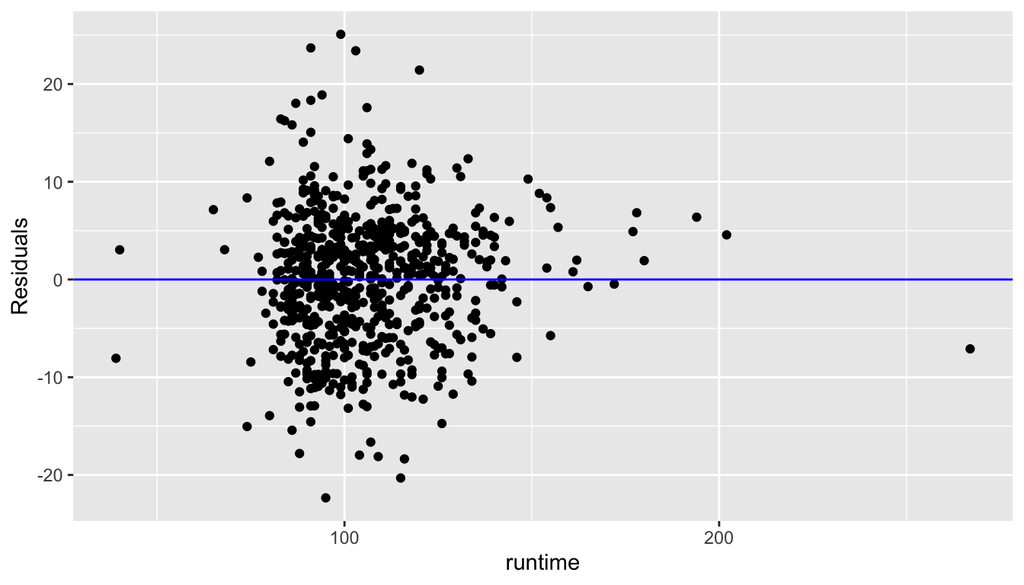

```r
ggplot(data = NULL, aes(x = movies$runtime[1:650], y = model0$residuals)) + geom_point() + geom_hline(yintercept = 0,color = 'blue') + xlab('runtime') + ylab('Residuals')
```

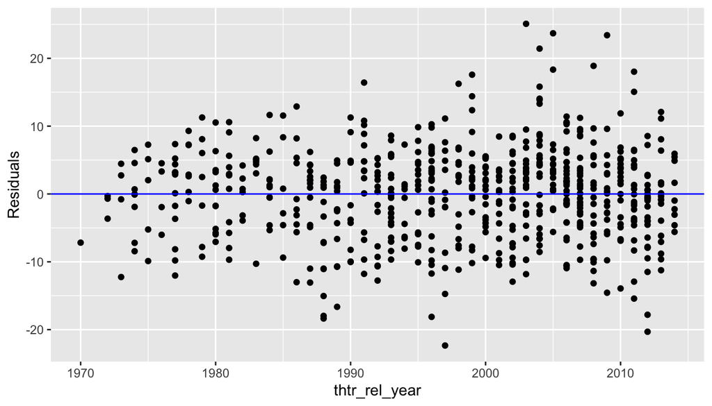

```r
ggplot(data = NULL, aes(x = movies$thtr_rel_year[1:650], y = model0$residuals)) + geom_point() + geom_hline(yintercept = 0,color = 'blue') + xlab('thtr_rel_year') + ylab('Residuals')
```

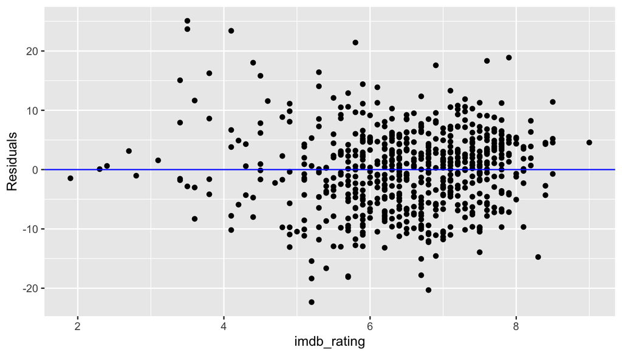

```r
ggplot(data = NULL, aes(x = movies$imdb_rating[1:650], y = model0$residuals)) + geom_point() + geom_hline(yintercept = 0,color = 'blue') + xlab('imdb_rating') + ylab('Residuals')
```

**Observations:**  
Above three plots shows that the residuals are random scattered around 0. and this requirement meeted.

**4.5.2 Nearly normal residuals with mean 0**

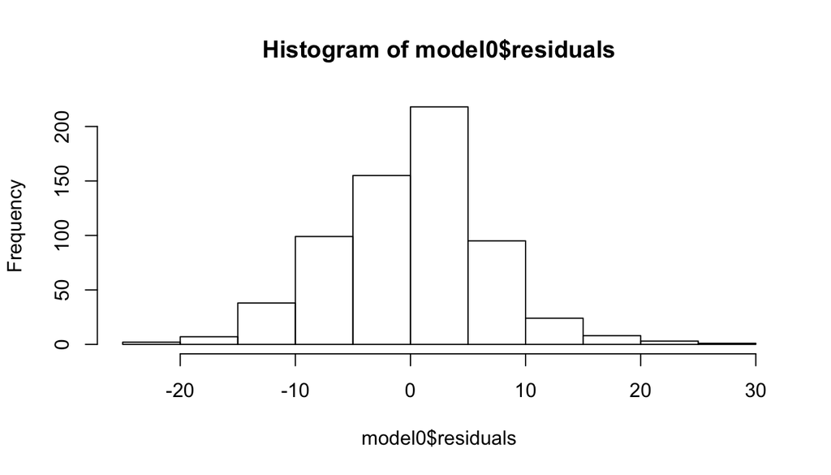

```r
hist(model0$residuals)
```

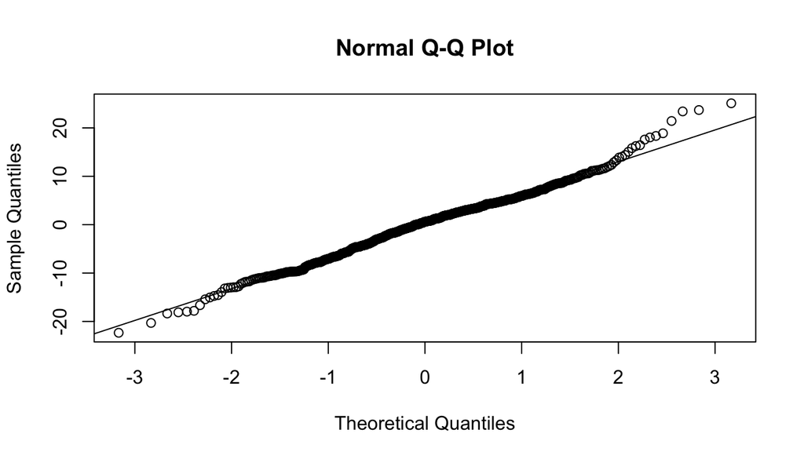

```r
qqnorm(model0$residuals)
qqline(model0$residuals)
```

**Observations:**  
The distribution seems normal in histogram, and in Q-Q plot it seems a little bit skew in the tail,but the deviations is small, so we can conclude this model meets the requirements.

**4.5.3 Constant variability of residuals**

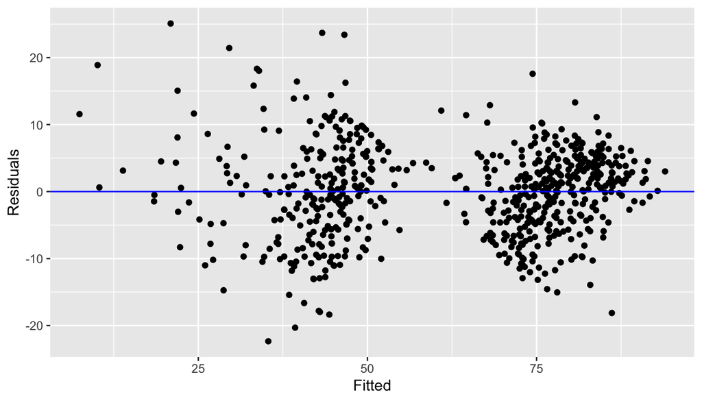

```r
ggplot(data = NULL, aes(x =model0$fitted, y = model0$residuals)) + geom_point() + geom_hline(yintercept = 0,color = 'blue') + xlab('Fitted') + ylab('Residuals')
```

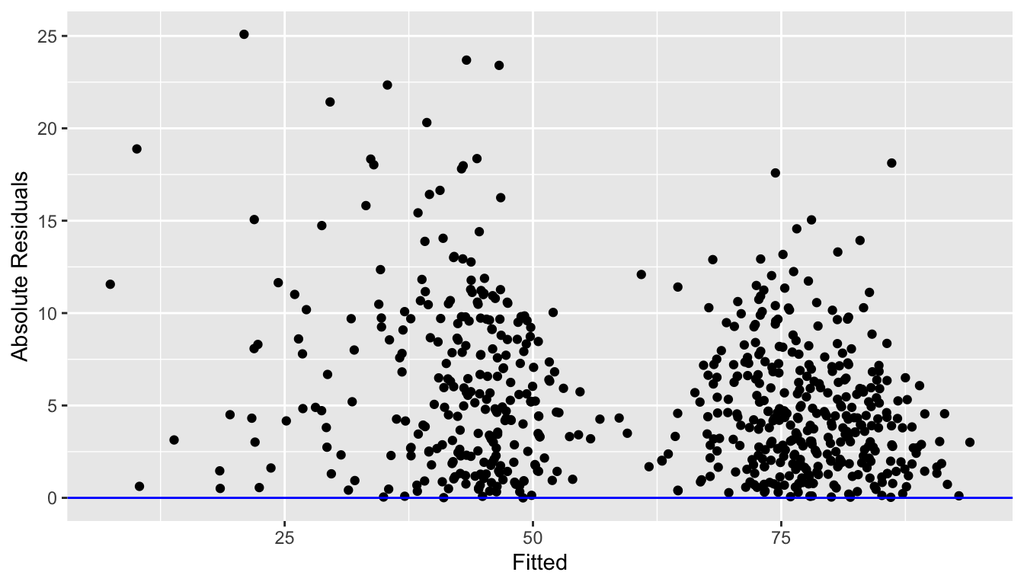

```r
ggplot(data = NULL, aes(x =model0$fitted, y = abs(model0$residuals))) + geom_point() + geom_hline(yintercept = 0,color = 'blue') + xlab('Fitted') + ylab('Absolute Residuals')
```

**4.5.4 Independent residuals**  
The data is random sampled, so the residuals are independent too.

## Part 5: Prediction

Now it’s test time, I decide to use movie John Wick: Chapter 2 to predict.  
**John Wick: Chapter 2**  
runtime: 122  
thtr_rel_time: 2017  
imdb_rating: 7.5 genre: Action & Adventure  
audience_rating: Upright  
best_pic_nom: no

actual audience_score: 85  
IMDb url: https://www.imdb.com/title/tt4425200/  
Rotten Tomatoes url: https://www.rottentomatoes.com/m/john_wick_chapter_2

```r
movie_test <- data.frame(runtime = 122, thtr_rel_year = 2017, imdb_rating = 7.5, genre = 'Action & Adventure', audience_rating = 'Upright', best_pic_nom = 'no')
predict(model0,movie_test, interval = 'predict',level = 0.95)
```

```
##        fit      lwr      upr
## 1 79.84505 66.25824 93.43186
```

**Results**  
The model we get predict the audience_score to be 79.85, given the above infomation, and it is close to the actual audience_score( 85% ).We also create a confidence interval for this movie, we are 95% confident that for given a movie with such information (runtime: 122, thtr_rel_time: 2017, imdb_rating: 7.5, genre: Action & Adventure , audience_rating: Upright, best_pic_nom: no), the audience score is expected to between 66.26 to 93.43.And the true audience score of this movie is in this interval.

## Part 6: Conclusion

In this project,I create a full model to predicte audience score for a movie, and I use backward elimination method to make model parsimoious,in this method, adjusted R square is a tool to judge the model is good or bad, also an expert opinion is importment. at last, I choose a movie, use this model to predict the audience score, and it works well.  
But there are some problems need to states:  
(1)When considering to genre , the data set is so small, almost half of the movies are ‘Drama’, and the number of two genres(‘Animation’, ‘Science Fiction & Fantasy’) movies are only 9, this would influence our modeling.  
(2)some variables like imdb_num_votes has a wide range, it would be more useful if we transform this variable.  
(3)some variables like imdb_rating and audience_score have higher variety when they are low,because good movie is suitable for more audience, but bad movie are not, some people may think it is good, some people may hate it. we may use some polynomial or non-linear regression to deal with it,and of course this is beyond our course.  
(4)more variables of movies may help our modeling.